# Day 1: Auto-Correlation – Defining the Problem & Selecting the Signal

## 1. Problem Statement (DD01)

Detect recurring patterns (annual cycles) in **Warsaw’s daily average temperature** to help find out **when** and **for how long** average temperatures falls between 0°C and -10°C.

## 2. Use Case (DD02)

City authorities in Warsaw need to **plan and budget** for winter road salting. By confirming the **seasonality** of temperatures in the 0°C to -10°C range, they can better allocate **salt supplies, equipment, and labor** during the times of year.

## 3. Objectives of the Experiments (DD03)

- We want to see how many days per year temperature is between 0°C to -10°C
- What time of the year temperature is between 0°C to -10°C

## 4. Why is This Relevant? (DD04)

- Knowing the pattern of sub-zero temperatures (0°C to -10°C) is **crucial** for road safety: if roads freeze, salting is necessary.
- Understanding **when** and **how often** these temperatures occur helps plan **logistics** and **budgets**.
- The city of Warsaw can **optimize salt usage** which can lead to savings in the city budget.
- Work schedules for personnel responsible for road salting can be better planned.

## 5. Selecting the Signal (DD05, DD06 and DD08)

The data source I'm using is the average day temperature is warsaw merused fro the same device for 1993-2022

Reference: https://www.kaggle.com/datasets/mateuszk013/warsaw-daily-weather/data

## 7. Additional Background (DD07)

In the past few years, the prices of road salt have been dramatically increasing. A few years ago, one ton of road salt cost 200 PLN (45 CHF), but now the price is around 800 PLN (180 CHF) per ton. Last year, because of embargoes on Belarus and Ukraine, Poland experienced a shortage of around 500 thousand tons of road salt. This finding hopefully helps with proper management of road salt so it will be used more effectively, which will bring economic advantages.

## TC1.1c: Could the repetitive pattern be demonstrated via auto-correlation?

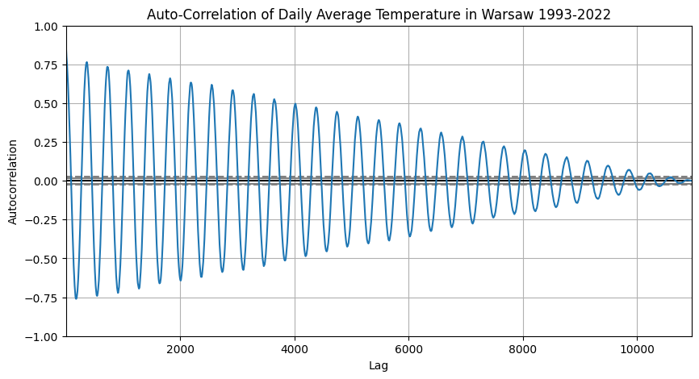

```python
import pandas as pd
import matplotlib.pyplot as plt
from pandas.plotting import autocorrelation_plot

df = pd.read_csv("warsaw_temperature.csv")
plt.figure(figsize=(10,5))
autocorrelation_plot(df["TAVG"])
plt.title("Auto-Correlation of Daily Average Temperature in Warsaw 1993-2022")
plt.show()
```

## Auto-Correlation Analysis of Warsaw Temperature Data (1993-2022)

### Key Findings

1. **Strong Seasonal Pattern**
   - Clear yearly cycles (peaks at ~365-day intervals)
   - Strong negative correlation at 180-day intervals
   - Demonstrates reliable temperature seasonality
2. **Correlation Strength**
   - Maximum positive correlation: ~0.75 at yearly intervals
   - Maximum negative correlation: ~-0.75 at half-year intervals
   - Gradual dampening of correlation strength over longer lags

### Conclusion

The auto-correlation analysis reveals robust seasonal patterns in Warsaw's temperature data, indicating that there are cyclic temperature patterns.